# The influencethe of age and gender on the covid-19’s ceses

Duoyi Zhang

2020-09-26T21:49:57-07:00

Abstract

I plot the variables:gender and age groups independently first.Then I try to relate them with the outcome ,and visulizie the relationship between them respectively.Despite the missing data and limitation of resources, I draw a conclusion that there exist a solid connection between age and the recovery rate.But there seem to be no difference beween the gender in front of the covid-19.

# Abstract:

I plot the variables:gender and age groups independently first.Then I try to relate them with the outcome ,and visulizie the relationship between them respectively.Despite the missing data and limitation of resources, I draw a conclusion that there exist a solid connection between age and the recovery rate.But there seem to be no difference beween the gender in front of the covid-19.

# Motivation:

Covid-19 has made the world totally different,it destroys many people’s life,make a lot of people unemployed ，many companies to shut down, even deprive of many people’s life.As a student who majors in Statistics in University of Toronto.I always hope I can make some contribution to the fight with covid-19.So I chose the topic :the relationship between gender, age , and the recovery rate of Covid-19 to discuss.

# Data

```
## # A tibble: 6 x 3
##   `Client Gender` Outcome  `Age Group`
##   <chr>           <chr>    <chr>
## 1 FEMALE          RESOLVED 50 to 59 Years
## 2 MALE            RESOLVED 50 to 59 Years
## 3 FEMALE          RESOLVED 20 to 29 Years
## 4 FEMALE          RESOLVED 60 to 69 Years
## 5 MALE            RESOLVED 60 to 69 Years
## 6 MALE            RESOLVED 50 to 59 Years
```

# Data visulizations

**Analysis and visulization for the “Client Gender”**:

```
##
##      FEMALE        MALE       OTHER TRANSGENDER     UNKNOWN
##        9427        8184           6           5         250
```

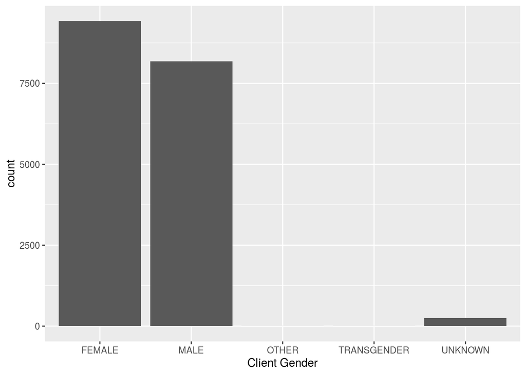

**Analysis and visulization for the “Age Group”**:

```
##
## 19 and younger 20 to 29 Years 30 to 39 Years 40 to 49 Years 50 to 59 Years
##           1311           3049           2724           2416           2720
## 60 to 69 Years 70 to 79 Years 80 to 89 Years   90 and older
##           1813           1133           1557           1116
```

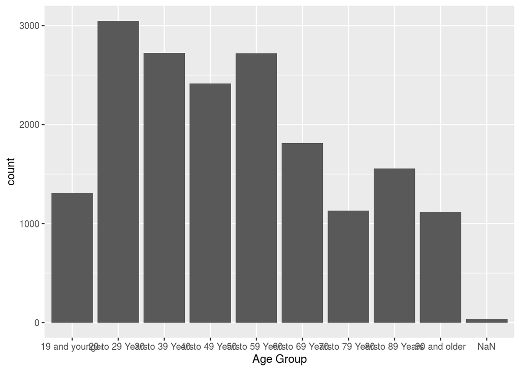

Since we cannot access the precise number for different groups,we cannot draw a solid conclusion here to analyze the infection rate of different ages.

**Visulaize the relationship between age and the outcome**

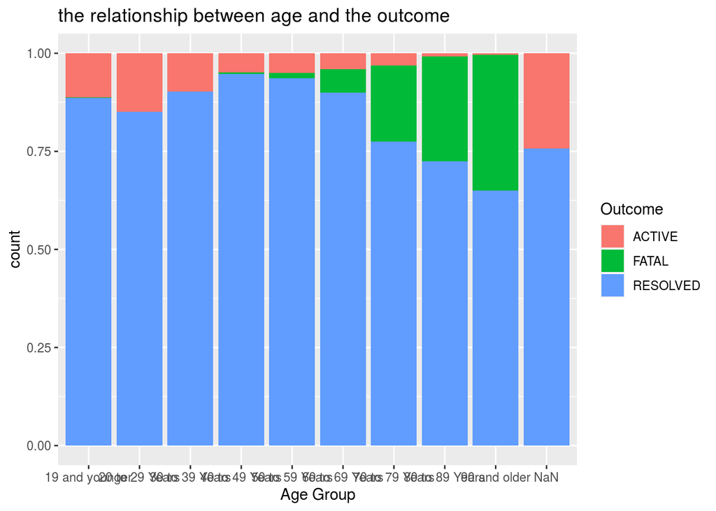

**Discussion**:

As the author of the dataset described,the interpretation of outcome is as follows: “Fatal: Cases with a fatal outcome reported. Resolved: Cases not reported as deceased, and who are either: Reported as ‘recovered’ OR Where the report date is more than 14 days from symptom onset AND the case is not currently hospitalized. This number is underreported due to a lag in data entry. Active: All other cases”

As seen on the plot,we can see an obvious difference between different age groups.There’s a decline on the ration of resolved cases after people reach 60.And for people who is under 60, the death rate is so small that is negligible.But there’s a huge rise of the fatal cases as people reach 60.We can see that,**the older of people, the higher posibilty of their illness cannot be recovered**.

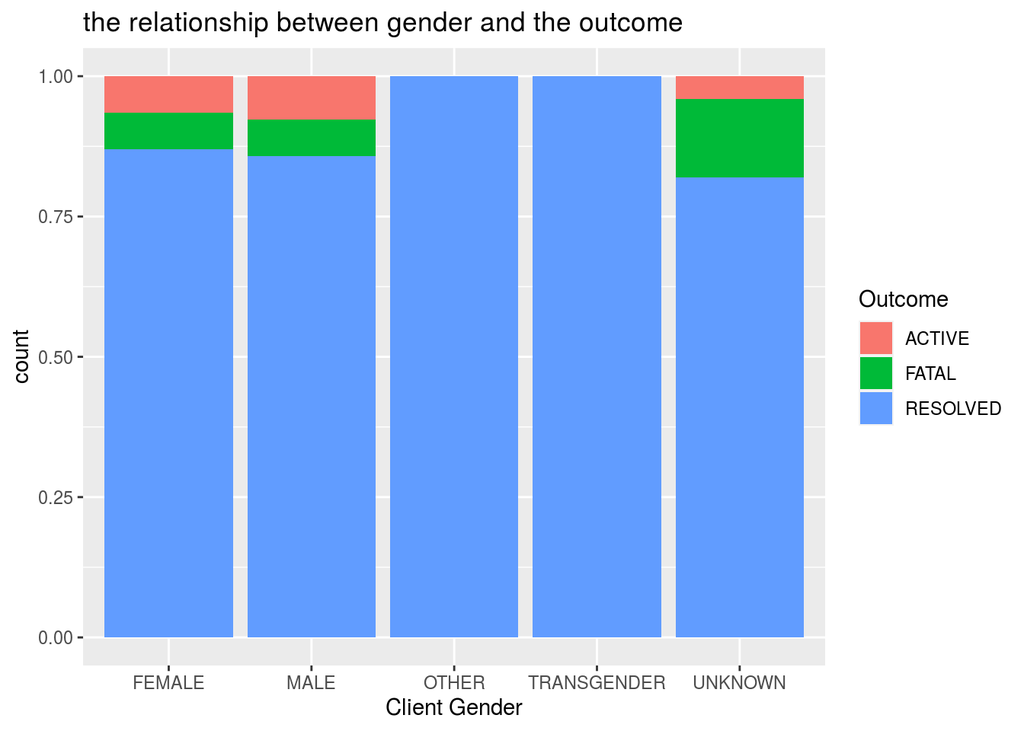

**Discussion**

In this graph, we can see despite the the data we cannot track,the resoloved ratio and fatal ratio in female and male is almost the same.We can conclude that in face of covid-19, women and men have the same ability to recover.There’s no difference between the gender.

# Conclusion of my analysis

From our analysis, we can conclude that people who are in different ages have the different ability to recover,but as for the gender, there is no difference ,men and women almost have the possibilty to be infected and be cured.The whole human race is a community.To fight with the scaring desease, we have to collabrate with each other.

## Weaknesses and next steps

Despite the weakness of the dataset(some data cannot be tracked and recorded which will make our analysis less reliable ),there are some weaknesses in our analysis.

In the future ,if I can have the accurate data ,I hope I can investigate more about the relationship between `Client Gender`, `Outcome` and `Age Group`. I hope the covid-19 analysis on the gender ,age can help the public have a deeper understanding about the desease, and help the government to implement more appropriate policies to fight it.

There are still interesting variables such as “Source of Infection”,"Neighbourhood Name’ that I do not discuss in this analysis.I hope in the future ,I can deal with them ,and make a far more comprehensive and valuable report.

# References

- Sharla Gelfand (2020). opendatatoronto: Access the City of Toronto Open Data Portal. https://sharlagelfand.github.io/opendatatoronto/, https://github.com/sharlagelfand/opendata
- Hadley Wickham, Jim Hester and Winston Chang (2020). devtools: Tools to Make Developing R Packages Easier. https://devtools.r-lib.org/,https://github.com/r-lib/devtools.
- R Core Team (2020). R: A language and environment for statistical computing. R, Foundation for Statistical Computing, Vienna, Austria. URL, https://www.R-project.org/.
- JJ Allaire and Yihui Xie and Jonathan McPherson and Javier Luraschi and Kevin Ushey and Aron Atkins and Hadley Wickham and Joe Cheng and Winston Chang and Richard Iannone (2020). rmarkdown: Dynamic Documents for R. R package version 2.3. URL https://rmarkdown.rstudio.com. -T2016 Census: Age and Sex; Type of Dwelling, Statistics Canada (2017) URL,https://www.toronto.ca/wp-content/uploads/2017/10/96d7-2016-Census-Backgrounder-Age-Sex-Dwelling-Type.pdf